# Your first AI application

Going forward, AI algorithms will be incorporated into more and more everyday applications. For example, you might want to include an image classifier in a smart phone app. To do this, you'd use a deep learning model trained on hundreds of thousands of images as part of the overall application architecture. A large part of software development in the future will be using these types of models as common parts of applications.

In this project, you'll train an image classifier to recognize different species of flowers. You can imagine using something like this in a phone app that tells you the name of the flower your camera is looking at. In practice you'd train this classifier, then export it for use in your application. We'll be using [this dataset](http://www.robots.ox.ac.uk/~vgg/data/flowers/102/index.html) of 102 flower categories, you can see a few examples below.

[figure not shown]

The project is broken down into multiple steps:

- Load and preprocess the image dataset
- Train the image classifier on your dataset
- Use the trained classifier to predict image content

We'll lead you through each part which you'll implement in Python.

When you've completed this project, you'll have an application that can be trained on any set of labeled images. Here your network will be learning about flowers and end up as a command line application. But, what you do with your new skills depends on your imagination and effort in building a dataset. For example, imagine an app where you take a picture of a car, it tells you what the make and model is, then looks up information about it. Go build your own dataset and make something new.

```python
# Imports here

%matplotlib inline
%config InlineBackend.figure_format = 'retina'

import time

import matplotlib.pyplot as plt
import numpy as np

import torch
from torch import nn, optim
import torch.nn.functional as F
from torch.autograd import Variable
from torchvision import datasets, models, transforms
```

## Load the data

Here you'll use `torchvision` to load the data ([documentation](http://pytorch.org/docs/master/torchvision/transforms.html#)). The data should be included alongside this notebook, otherwise you can [download it here](https://s3.amazonaws.com/content.udacity-data.com/nd089/flower_data.tar.gz). The dataset is split into three parts, training, validation, and testing. For the training, you'll want to apply transformations such as random scaling, cropping, and flipping. This will help the network generalize leading to better performance. You'll also need to make sure the input data is resized to 224x224 pixels as required by the pre-trained networks.

The validation and testing sets are used to measure the model's performance on data it hasn't seen yet. For this you don't want any scaling or rotation transformations, but you'll need to crop them images to the appropriate size.

For all three sets you'll need to normalize the means and standard deviations of the images to what the network expects. For the means, it's `[0.485, 0.456, 0.406]` and for the standard deviations `[0.229, 0.224, 0.225]`.

```python
train_dir = 'train'
valid_dir = 'valid'
test_dir = 'test'
```

```python
data_transforms = {
    'train': transforms.Compose([
        transforms.RandomRotation(45),
        transforms.RandomResizedCrop(224),
        transforms.RandomHorizontalFlip(),
        transforms.ToTensor(),
        transforms.Normalize([0.485, 0.456, 0.406], [0.229, 0.224, 0.225])
    ]),
    'valid': transforms.Compose([
        transforms.Resize(256),
        transforms.CenterCrop(224),
        transforms.ToTensor(),
        transforms.Normalize([0.485, 0.456, 0.406], [0.229, 0.224, 0.225])
    ]),
    'test': transforms.Compose([
        transforms.Resize(256),
        transforms.CenterCrop(224),
        transforms.ToTensor(),
        transforms.Normalize([0.485, 0.456, 0.406], [0.229, 0.224, 0.225])
    ]),
}

dirs = {'train': train_dir, 'valid': valid_dir, 'test': test_dir}
image_datasets = {x: datasets.ImageFolder(dirs[x], transform=data_transforms[x])
                  for x in ['train', 'valid', 'test']}

dataloaders = {x: torch.utils.data.DataLoader(image_datasets[x], batch_size=32,
                                              shuffle=True)
               for x in ['train', 'valid', 'test']}
```

### Label mapping

You'll also need to load in a mapping from label to category name. You can find this in the file `label_map.json`. It's a JSON object which you can read in with the [`json` module](https://docs.python.org/2/library/json.html). This will give you a dictionary mapping the integer coded labels to the actual names of the flowers.

```python
import json

with open('label_map.json', 'r') as f:
    label_map = json.load(f)
```

# Building and training the classifier

Now that the data is ready, it's time to build and train the classifier. As usual, you should use one of the pretrained models from `torchvision.models` to get the image features. Build and train a new feed-forward classifier using those features.

We're going to leave this part up to you. If you want to talk through it with somene, chat with your fellow students! You can also ask questions on the forums or join the instructors in office hours.

- Load a pre-trained network
- Define a new, untrained feed-forward network as a classifier, using ReLU activations and dropout
- Train the classifier layers using backpropagation
- Track the loss and accuracy on the validation set to determine the best hyperparameters
- Save the trained model to a checkpoint

```python
class FFClassifier(nn.Module):

    def __init__(self, in_features, hidden_features, out_features, drop_prob=0.5):
        super(FFClassifier, self).__init__()

        self.fc1 = nn.Linear(in_features, hidden_features)
        self.fc2 = nn.Linear(hidden_features, hidden_features)
        self.fc3 = nn.Linear(hidden_features, out_features)

        self.drop = nn.Dropout(p=drop_prob)

    def forward(self, x):
        x = self.drop(F.relu(self.fc1(x)))
        x = self.drop(F.relu(self.fc2(x)))
        x = self.fc3(x)

        x = F.log_softmax(x, dim=1)
        return x
```

```python
model_names = sorted(name for name in models.__dict__
    if name.islower() and not name.startswith("__")
    and callable(models.__dict__[name]))

arch = 'vgg16' #available choices are 'vgg11', 'vgg11_bn', 'vgg13', 'vgg13_bn', 'vgg16', 'vgg16_bn', 'vgg19',
               #'vgg19_bn', 'alexnet', 'resnet101', 'resnet152', 'resnet18', 'resnet34', 'resnet50'
fc_hidden = 4096
fc_out = len(label_map)
drop_prob = 0.5
learning_rate = 0.001

model = models.__dict__[arch](pretrained=True)
for param in model.parameters():
    param.requires_grad = False

if arch.startswith('vgg'):
    fc_in = model.classifier[0].in_features
    model.classifier = FFClassifier(fc_in, fc_hidden, fc_out, drop_prob)
    criterion = nn.CrossEntropyLoss()
    optimizer = optim.Adam(model.classifier.parameters(), lr=learning_rate)
elif arch.startswith('alexnet'):
    fc_in = model.classifier[1].in_features
    model.classifier = FFClassifier(fc_in, fc_hidden, fc_out, drop_prob)
    criterion = nn.CrossEntropyLoss()
    optimizer = optim.Adam(model.classifier.parameters(), lr=learning_rate)
elif arch.startswith('res'):
    model.fc = FFClassifier(model.fc.in_features, fc_hidden, fc_out, drop_prob)
    criterion = nn.CrossEntropyLoss()
    optimizer = optim.Adam(model.fc.parameters(), lr=learning_rate)
```

```python
model
```

```
VGG(
  (features): Sequential(
    (0): Conv2d (3, 64, kernel_size=(3, 3), stride=(1, 1), padding=(1, 1))
    (1): ReLU(inplace)
    (2): Conv2d (64, 64, kernel_size=(3, 3), stride=(1, 1), padding=(1, 1))
    (3): ReLU(inplace)
    (4): MaxPool2d(kernel_size=(2, 2), stride=(2, 2), dilation=(1, 1))
    (5): Conv2d (64, 128, kernel_size=(3, 3), stride=(1, 1), padding=(1, 1))
    (6): ReLU(inplace)
    (7): Conv2d (128, 128, kernel_size=(3, 3), stride=(1, 1), padding=(1, 1))
    (8): ReLU(inplace)
    (9): MaxPool2d(kernel_size=(2, 2), stride=(2, 2), dilation=(1, 1))
    (10): Conv2d (128, 256, kernel_size=(3, 3), stride=(1, 1), padding=(1, 1))
    (11): ReLU(inplace)
    (12): Conv2d (256, 256, kernel_size=(3, 3), stride=(1, 1), padding=(1, 1))
    (13): ReLU(inplace)
    (14): Conv2d (256, 256, kernel_size=(3, 3), stride=(1, 1), padding=(1, 1))
    (15): ReLU(inplace)
    (16): MaxPool2d(kernel_size=(2, 2), stride=(2, 2), dilation=(1, 1))
    (17): Conv2d (256, 512, kernel_size=(3, 3), stride=(1, 1), padding=(1, 1))
    (18): ReLU(inplace)
    (19): Conv2d (512, 512, kernel_size=(3, 3), stride=(1, 1), padding=(1, 1))
    (20): ReLU(inplace)
    (21): Conv2d (512, 512, kernel_size=(3, 3), stride=(1, 1), padding=(1, 1))
    (22): ReLU(inplace)
    (23): MaxPool2d(kernel_size=(2, 2), stride=(2, 2), dilation=(1, 1))
    (24): Conv2d (512, 512, kernel_size=(3, 3), stride=(1, 1), padding=(1, 1))
    (25): ReLU(inplace)
    (26): Conv2d (512, 512, kernel_size=(3, 3), stride=(1, 1), padding=(1, 1))
    (27): ReLU(inplace)
    (28): Conv2d (512, 512, kernel_size=(3, 3), stride=(1, 1), padding=(1, 1))
    (29): ReLU(inplace)
    (30): MaxPool2d(kernel_size=(2, 2), stride=(2, 2), dilation=(1, 1))
  )
  (classifier): FFClassifier(
    (fc1): Linear(in_features=25088, out_features=4096)
    (fc2): Linear(in_features=4096, out_features=4096)
    (fc3): Linear(in_features=4096, out_features=102)
    (drop): Dropout(p=0.5)
  )
)
```

```python
#as the same function is used for calculating the validation and test losses and accuracies, I have used an
#argumnet 'is_test' to check whether the data is validation data or test data.
def validation(model, val_data, criterion, cuda=False, is_test=False):
    val_start = time.time()
    running_val_loss = 0
    accuracy = 0
    for inputs, labels in val_data:
        inputs, labels = Variable(inputs), Variable(labels)

        if cuda:
            inputs, labels = inputs.cuda(), labels.cuda()


        outputs = model.forward(inputs)
        val_loss = criterion(outputs, labels)

        ps = torch.exp(outputs.data)

        _, predicted = ps.max(dim=1)

        equals = predicted == labels.data
        #casting to float is necessary as the torch.sum(equals) and len(equals) are both integer
        accuracy += float(torch.sum(equals))/len(equals)

        running_val_loss += val_loss.data[0]
    val_time = time.time() - val_start
    if not is_test:
        #instead of diving by len(dataloaders['valid'], I have divided by len(val_data) as we are reusing the
        #function to calculate both validation and training loss.
        print("Validion loss: {:.3f}".format(running_val_loss/len(val_data)),
              "Validation Accuracy: {:.3f}".format(accuracy/len(val_data)),
              "Validation time: {:.3f} s/batch".format(val_time/len(val_data)))
    else:
        print("Test loss: {:.3f}".format(running_val_loss/len(val_data)),
              "Test Accuracy: {:.3f}".format(accuracy/len(val_data)),
              "Test time: {:.3f} s/batch".format(val_time/len(val_data)))
```

```python
epochs = 10
cuda = True
print_every_n = 50

if cuda:
    model.cuda()
else:
    model.cpu()

model.train()

#Here I have not used the new f-strings as they are only availabel in python 3.6, instead I have used format
for e in range(epochs):
    print("Epoch  "+str(e+1)+'/'+str(epochs))
    counter = 0
    running_loss = 0
    for inputs, labels in dataloaders['train']:
        counter += 1

        # Training pass
        inputs, labels = Variable(inputs), Variable(labels)

        if cuda:
            inputs, labels = inputs.cuda(), labels.cuda()

        optimizer.zero_grad()

        outputs = model.forward(inputs)
        loss = criterion(outputs, labels)
        loss.backward()
        optimizer.step()
        running_loss += loss.data[0]

        if counter % print_every_n == 0:
            print("Step: {}".format(counter))
            print("Training loss {:.3f}".format(running_loss/counter))
            model.eval()
            validation(model, dataloaders['valid'], criterion, cuda=cuda)
            model.train()
    else:
        # Validation pass
        train_end = time.time()
        model.eval()
        validation(model, dataloaders['valid'], criterion, cuda=cuda)
```

```
Epoch  1/10
Step: 50
Training loss 2.725
('Validion loss: 1.455', 'Validation Accuracy: 0.695', 'Validation time: 0.398 s/batch')
Step: 100
Training loss 2.778
('Validion loss: 1.454', 'Validation Accuracy: 0.673', 'Validation time: 0.399 s/batch')
Step: 150
Training loss 2.763
('Validion loss: 1.487', 'Validation Accuracy: 0.670', 'Validation time: 0.400 s/batch')
Step: 200
Training loss 2.748
('Validion loss: 1.478', 'Validation Accuracy: 0.673', 'Validation time: 0.401 s/batch')
('Validion loss: 1.459', 'Validation Accuracy: 0.682', 'Validation time: 0.403 s/batch')
Epoch  2/10
Step: 50
Training loss 1.351
('Validion loss: 0.919', 'Validation Accuracy: 0.755', 'Validation time: 0.413 s/batch')
Step: 100
Training loss 2.056
('Validion loss: 1.316', 'Validation Accuracy: 0.724', 'Validation time: 0.402 s/batch')
Step: 150
Training loss 2.254
('Validion loss: 1.435', 'Validation Accuracy: 0.685', 'Validation time: 0.403 s/batch')
Step: 200
Training loss 2.404
('Validion loss: 1.472', 'Validation Accuracy: 0.700', 'Validation time: 0.407 s/batch')
('Validion loss: 1.498', 'Validation Accuracy: 0.687', 'Validation time: 0.406 s/batch')
Epoch  3/10
Step: 50
Training loss 1.423
('Validion loss: 0.836', 'Validation Accuracy: 0.781', 'Validation time: 0.402 s/batch')
Step: 100
Training loss 2.033
('Validion loss: 1.203', 'Validation Accuracy: 0.718', 'Validation time: 0.400 s/batch')
Step: 150
Training loss 2.269
('Validion loss: 1.299', 'Validation Accuracy: 0.723', 'Validation time: 0.399 s/batch')
Step: 200
Training loss 2.367
```

[output cut: 85 more lines]

```
('Validion loss: 1.276', 'Validation Accuracy: 0.726', 'Validation time: 0.411 s/batch')
Epoch  10/10
Step: 50
Training loss 1.141
('Validion loss: 0.769', 'Validation Accuracy: 0.827', 'Validation time: 0.408 s/batch')
Step: 100
Training loss 1.972
('Validion loss: 1.300', 'Validation Accuracy: 0.736', 'Validation time: 0.402 s/batch')
Step: 150
Training loss 2.153
('Validion loss: 1.175', 'Validation Accuracy: 0.748', 'Validation time: 0.398 s/batch')
Step: 200
Training loss 2.263
('Validion loss: 1.267', 'Validation Accuracy: 0.725', 'Validation time: 0.400 s/batch')
('Validion loss: 1.263', 'Validation Accuracy: 0.731', 'Validation time: 0.400 s/batch')
```

## Testing your network

It's good practice to test your trained network on test data, images the network has never seen either in training or validation. This will give you a good estimate for the model's performance on completely new images. You should be able to reach around 70% accuracy on the test set if the model has been trained well.

```python
model.cuda()
model.eval()
validation(model, dataloaders['test'], criterion, cuda=True, is_test=True)
```

```
('Test loss: 1.333', 'Test Accuracy: 0.735', 'Test time: 0.404 s/batch')
```

## Save the checkpoint

Now that your network is trained, save the model so you can load it later for making predictions. You probably want to save other things such as the mapping of indices to classes which you get from one of the image datasets: `image_datasets['train'].class_to_idx`. You can attach this to the model as an attribute which makes inference easier later on.

Remember that you'll want to completely rebuild the model later so you can use it for inference. Make sure to include any information you need in the checkpoint. If you want to load the model and keep training, you'll want to save the number of epochs as well as the optimizer state, `optimizer.state_dict`.

```python
model.class_to_idx = image_datasets['train'].class_to_idx
model.cpu()
torch.save({'arch': arch,
            'hidden': fc_hidden,
            'drop_prob':  drop_prob,
            'state_dict': model.state_dict(),
            'class_to_idx': model.class_to_idx},
            'clssifier.pt')
```

## Loading the checkpoint

At this point it's good to write a function that can load a checkpoint and rebuild the model.

```python
def load_model(checkpoint_path):
    checkpoint = torch.load(checkpoint_path)
    model = models.__dict__[checkpoint['arch']](pretrained=True)
    model.class_to_idx = checkpoint['class_to_idx']

    if checkpoint['arch'].startswith('vgg'):
        fc_in = model.classifier[0].in_features
        model.classifier = FFClassifier(fc_in, checkpoint['hidden'], len(model.class_to_idx), checkpoint['drop_prob'])
    elif checkpoint['arch'].startswith('alexnet'):
        fc_in = model.classifier[1].in_features
        model.classifier = FFClassifier(fc_in, checkpoint['hidden'], len(model.class_to_idx), checkpoint['drop_prob'])
    elif checkpoint['arch'].startswith('res'):
        model.fc = FFClassifier(model.fc.in_features, checkpoint['hidden'], len(model.class_to_idx), checkpoint['drop_prob'])

    model.load_state_dict(checkpoint['state_dict'])

    return model
```

```python
model = load_model('classifier.pt')
```

[output not shown]

# Inference for classification

Now write a function to use a trained network for inference. That is, you'll pass an image into the network and predict the class of the flower in the image. Write a function called `predict` that takes an image and a model, then returns the top $K$ most likely classes along with the probabilities. It should look like

```
probs, classes = predict(image_path, model)
print(probs)
print(classes
> [ 0.01558163  0.01541934  0.01452626  0.01443549  0.01407339]
> ['70', '3', '45', '62', '55']
```

First you'll need to handle processing the input image such that it can be used in your network.

## Image Preprocessing

You'll want to use `PIL` to load the image ([documentation](https://pillow.readthedocs.io/en/latest/reference/Image.html)). It's best to write a function that preprocesses the image so it can be used as input for the model. This function should process the images in the same manner used for training.

First, resize the images where the shortest side is 256 pixels, keeping the aspect ratio. This can be done with the [`thumbnail`](http://pillow.readthedocs.io/en/3.1.x/reference/Image.html#PIL.Image.Image.thumbnail) or [`resize`](http://pillow.readthedocs.io/en/3.1.x/reference/Image.html#PIL.Image.Image.thumbnail) methods. Then you'll need to crop out the center 224x224 portion of the image.

Color channels of images are typically encoded as integers 0-255, but the model expected floats 0-1. You'll need to conversion, it's easiest with a Numpy array, which you can get from a PIL image like so `np_image = np.array(pil_image)`.

As before, the network expects the images to be normalized in a specific way. For the means, it's `[0.485, 0.456, 0.406]` and for the standard deviations `[0.229, 0.224, 0.225]`. You'll want to subtract the means from each color channel, then divide by the standard deviation.

And finally, PyTorch expects the color channel to be the first dimension but it's the third dimension in the PIL image and Numpy array. You can reorder dimensions using [`ndarray.transpose`](https://docs.scipy.org/doc/numpy-1.13.0/reference/generated/numpy.ndarray.transpose.html). The color channel needs to be first and retain the order of the other two dimensions.

```python
from PIL import Image
```

```python
def process_image(image):
    ''' Scales, crops, and normalizes a PIL image for a PyTorch model '''

    # Resize and crop out the center 224x224 square
    aspect = image.size[0]/image.size[1]
    if aspect > 0:
        image.thumbnail((10000, 256))
    else:
        image.thumbnail((256, 10000))
    left_margin = (image.width-224)/2
    top_margin = (image.height-224)/2
    image = image.crop((left_margin, top_margin, left_margin+224, top_margin+224))

    # Now normalize...
    image = np.array(image)/255
    mean = np.array([0.485, 0.456, 0.406])
    std = np.array([0.229, 0.224, 0.225])
    image = (image - mean)/std

    # Move color channels to first dimension as expected by PyTorch
    image = image.transpose((2, 0, 1))

    return image
```

```python
image_path = 'test/28/image_05230.jpg'
image = Image.open(image_path)
image = process_image(image)
```

## Class Prediction

To get the top $K$ largest values in a tensor use [`x.topk(k)`](http://pytorch.org/docs/master/torch.html#torch.topk). This method returns both the highest `k` probabilities and the indices of those probabilities corresponding to the classes. You need to convert from these indices to the actual class labels using `class_to_idx` which hopefully you added to the model or from an `ImageFolder` you used to load the data.

```python
def predict(image_path, model, topk=5):
    image = Image.open(image_path)
    image = process_image(image)

    # Convert to PyTorch tensor and do a forward pass
    # Model expects a FloatTensor, from_numpy gives a DoubleTensor
    image_tensor = torch.from_numpy(image).type(torch.FloatTensor)
    inputs = Variable(image_tensor, requires_grad=False)
    inputs = inputs.unsqueeze(0)

    ps = torch.exp(model.forward(inputs))

    top_probs, top_labels = ps.topk(topk)

    #if we use gpu here, we need to use .cpu() to move the tensor to host memory first.
    top_probs, top_labels = top_probs.cpu().data.numpy().squeeze(), top_labels.cpu().data.numpy().squeeze()

    #top_probs, top_labels = top_probs.data.numpy().squeeze(), top_labels.data.numpy().squeeze()

    # Convert indices to classes
    idx_to_class = {val: key for key, val in model.class_to_idx.items()}
    top_classes = [idx_to_class[each] for each in top_labels]

    return top_probs, top_classes
```

```python
image_path = 'test/28/image_05230.jpg'
model.eval()
model.cpu()
predict(image_path, model)
```

```
(array([0.11349957, 0.09422939, 0.08990259, 0.06337839, 0.04768424],
       dtype=float32), ['77', '79', '57', '21', '14'])
```

## Sanity Checking

Now that you can use a trained model for predictions, check to make sure it makes sense. Even if the testing accuracy is high, it's always good to check there aren't obvious bugs. Use `matplotlib` to plot the probabilities for the top 5 classes as a bar graph, along with the input image. It should look like this:

[figure not shown]

You can convert from the class integer encoding to actual flower names with the `label_map.json` file.

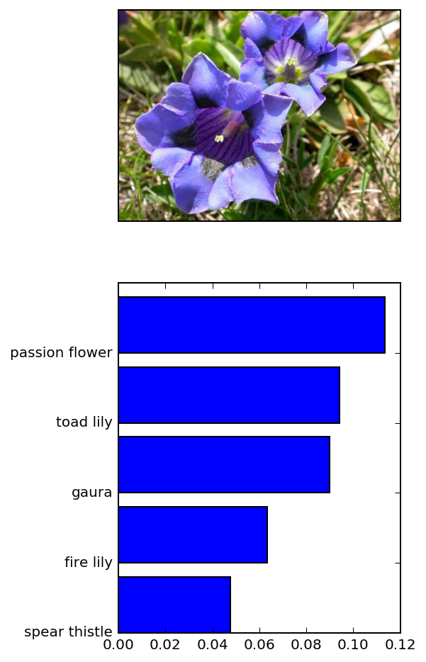

```python
image_path = 'test/28/image_05230.jpg'

model.eval()
top_probs, top_classes = predict(image_path, model)
image = Image.open(image_path)
image = np.array(image)

fig, (img_ax, p_ax) = plt.subplots(figsize=(4,7), nrows=2)
img_ax.imshow(image)
img_ax.xaxis.set_visible(False)
img_ax.yaxis.set_visible(False)

p_ax.barh(np.arange(5, 0, -1), top_probs)
top_cat_names = [label_map[each] for each in top_classes]
p_ax.set_yticks(range(1,6))
p_ax.set_yticklabels(reversed(top_cat_names));
fig.tight_layout(pad=0.1, h_pad=0)
```

```python
images, labels = next(iter(dataloaders['test']))
```

```python
def imshow(image, ax=None, title=None):
    """Imshow for Tensor."""
    if ax is None:
        fig, ax = plt.subplots()
    image = image.numpy().transpose((1, 2, 0))
    mean = np.array([0.485, 0.456, 0.406])
    std = np.array([0.229, 0.224, 0.225])
    image = std * image + mean
    image = np.clip(image, 0, 1)
    ax.imshow(image)

    return ax
```

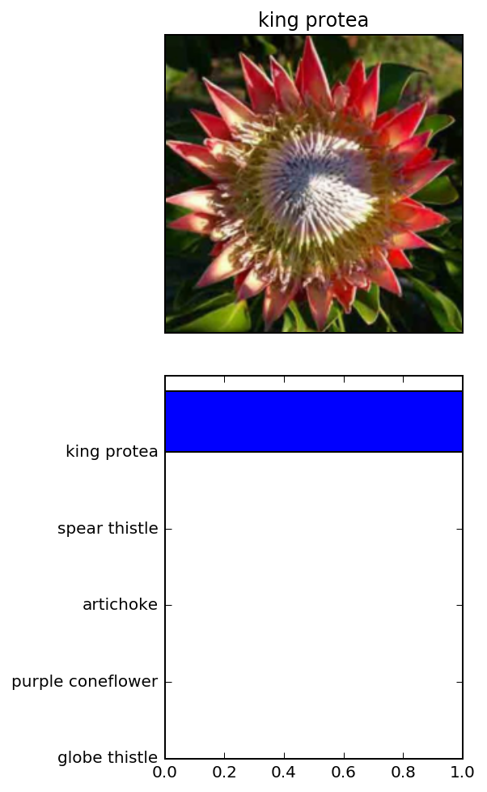

```python
img_idx = 20

inputs = Variable(images[img_idx,:].unsqueeze(0))
model.eval()
model.cpu()
ps = torch.exp(model.forward(inputs))

top_probs, top_classes = ps.topk(5)
idx_to_class = {val: key for key, val in model.class_to_idx.items()}
top_classes = [idx_to_class[each] for each in top_classes.data.squeeze()]

fig, (img_ax, p_ax) = plt.subplots(figsize=(4,7), nrows=2)
img_ax = imshow(inputs.data.squeeze(), ax=img_ax)
img_ax.set_title(label_map[idx_to_class[labels[img_idx]]])
img_ax.xaxis.set_visible(False)
img_ax.yaxis.set_visible(False)

p_ax.barh(np.arange(5, 0, -1), top_probs.data.numpy().squeeze())
top_cat_names = [label_map[each] for each in top_classes]
p_ax.set_yticks(range(1,6))
p_ax.set_yticklabels(reversed(top_cat_names));
fig.tight_layout(pad=0.1, h_pad=0)
```